# **[Universidade Federal Rural de Pernambuco](http://ufrpe.br/)** **[Departamento de Matemática](http://www.dm.ufrpe.br/)** **[Disciplina: Análise Combinatória](https://sites.google.com/site/ricardonunesmachadojr/disciplinas/analise-combinatoria)** **[Prof. Ricardo Machado](https://sites.google.com/site/ricardonunesmachadojr/)**

## [Índice de Aulas](https://sagectu.com.br/calculo1.github.io/combinatoria.html) Aula 5

## 1 - O Princípio da Inclusão-Exclusão para dois conjuntos 2 - O Princípio da Inclusão-Exclusão para três conjuntos 3 - O Princípio da Inclusão-Exclusão para $n$ conjuntos 4 - Exercícios 5 - Atividade 6 - Resposta dos Exercícios

# Referências:

### Observação: Nota de aula produzida usando o software [SageMath](http://www.sagemath.org/), usando o notebook [Jupyter](https://jupyter.org/). Use o SageMathCell com vários exemplos em: sagectu.com.br/sagecell.html Referência bibliográfica sobre o SageMath: [1] Silva, L., Santos M., Machado, R., [*Elementos de Computação Matemática com SageMath*](https://sagectu.com.br/), SBM, 2019.

[figure not shown]

```python
load ('/home/ricardo/sage-9.0-Debian_GNU_Linux_9-x86_64/SageMath/Sage_Sync/Combinatoria/codigos.sage')
```

## Observação O material dessa nota de aula foi baseado na referência [3].

## 1 - O Princípio da Inclusão-Exclusão para dois conjuntos

### Notação Usaremos o símbolo $\#A$ para representar o número de elementos do conjunto $A$, isto é, a cardinalidade de $A$.

### Teorema 1 Sejam $A$ e $B$ conjuntos finitos, então $$\#(A\cup B)=\#A+\#B-\#(A\cap B)$$

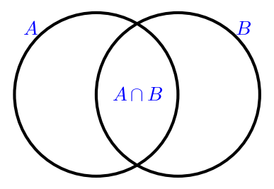

```python
diag_venn(2)
```

### Demonstração Sejam $A$ e $B$ conjuntos finitos, $T_1$ a tarefa de selecionar um elemento de $A$ e $T_2$ a tarefa de selecionar um elemento de $B$. Existem $\#A$ maneiras de realizar $T_1$ e $\#B$ maneiras de realizar $T_2$. O número de maneiras de executar $T_1$ ou $T_2$ é a soma do número de maneiras de executar $T_1$ e o número de maneiras de executar $T_2$ menos o número de maneiras de executar ambos $T_1$ e $T_2$, pois esta quantidade já foi contada duas vezes. Como existem $\#(A\cup B)$ maneiras de realizar $T_1$ ou $T_2$ e $\#(A\cap B)$ maneiras de realizar $T_1$ e $T_2$, temos: \begin{equation} \#(A\cup B)=\#A+\#B-\#(A\cap B) \end{equation} $\blacksquare$

### Exemplo 1 Numa pesquisa com jovens foram feitas as seguintes perguntas para que respondessem sim ou não. Gosta de exatas? Gosta de humanas? Responderam sim a primeira pergunta 80 jovens, 60 reponderam sim a segunda e 15 responderam sim a ambas. Quantos jovens foram entrevistados?

### Solução $\bullet$ $A=\{\text{alunos que gostam de exatas}\}$, $\#A=80$ $\bullet$ $B=\{\text{alunos que gostam de humanas}\}$, $\#B=60$ $\bullet$ $(A\cap B)=\{\text{alunos que gostam de ambas as áreas}\}$, $\#(A\cap B)=15$ Dessa forma, fazendo $\#A+\#B$ o número de alunos que gostam de ambas as áreas é contado duas vezes. Assim, para determinar o número de alunos entrevistados retira-se o número de alunos que foi contado duas vezes, ou seja \begin{equation*} \begin{split} \#(A\cup B)= &~\#A+\#B-\#(A\cap B)\\ = & ~ 80 + 60-15\\ = & ~125 \end{split} \end{equation*} $\blacksquare$

## 2 - O Princípio da Inclusão-Exclusão para três conjuntos

### Teorema 2 Sejam $A, B$ e $C$ conjuntos finitos, então \begin{equation} \begin{split} \#(A\cup B\cup C)= & ~ \#(A)+\#(B)+\#(C)\\ &~ -\#(A\cap B)-\#(A\cap C)-\#(B\cap C)\\ & ~+\#(A\cap B\cap C) \end{split} \end{equation}

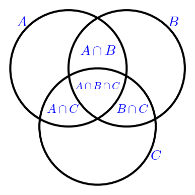

```python
diag_venn(3)
```

### Demonstração Considere $(A\cup B)$ como um conjunto, usando o Teorema 1 temos: \begin{equation*} \begin{split} \#[A\cup B\cup C]= & \#[(A\cup B)\cup C] \\ = & \#(A\cup B)+\#C-\#[(A\cup B)\cap C]\\ = & \#A+\#B-\#(A\cap B)+\#C-\#[(A\cup B)\cap C] \end{split} \end{equation*} Usando a igualdade: $$ (A\cup B)\cap C = (A\cap C)\cup (B\cap C), $$ temos \begin{equation*} \begin{split} \#[A\cup B\cup C]= & \#A+\#B-\#(A\cap B)+\#C-\#[(A\cap C)\cup (B\cap C)]\\ = & \#A+\#B-\#(A\cap B)+\#C-\#(A\cap C)-\#(B\cap C)+\#(A\cap B\cap C)\\ = & \#A+\#B+\#C-\#(A\cap B)-\#(A\cap C)-\#(B\cap C)+\#(A\cap B\cap C) \end{split} \end{equation*} $\blacksquare$

## 3 - O Princípio da Inclusão-Exclusão para $n$ conjuntos

### Exemplo Quantos são os anagramas da palavra COMPLEXA que tem C em 1º lugar, ou O em 2º lugar, ou M em 3º lugar ou P em 4º lugar?

### Solução $\bullet$ $A_1=\{\text{anagramas de COMPLEXA que tem C em 1º lugar}\}$, $\#A_1 = 7!$ $\bullet$ $A_2=\{\text{anagramas de COMPLEXA que tem O em 2º lugar}\}$, $\#A_2 = 7!$ $\bullet$ $A_3=\{\text{anagramas de COMPLEXA que tem M em 3º lugar}\}$, $\#A_3 = 7!$ $\bullet$ $A_4=\{\text{anagramas de COMPLEXA que tem P em 4º lugar}\}$, $\#A_4 = 7!$ $\bullet$ $\#(A_i\cap A_j)$, $1\leq i< j\leq 4$. É o número de anagramas da palavra COMPLEXA que tem as letras nas posições $i, j$ fixas. $$\#(A_i\cap A_j) = 6!$$ $\bullet$ $\#(A_i\cap A_j\cap A_k)$, $1\leq i< j\leq 4$. É o número de anagramas da palavra COMPLEXA que tem as letras nas posições $i, j, k$ fixas. $$\#(A_i\cap A_j\cap A_k) = 5!$$ $\bullet$ $\#(A_1\cap A_2\cap A_3\cap A_4)$ é o número de anagramas da palavra COMPLEXA que tem as letras nas posições $1, 2, 3, 4$ fixas. $$\#(A_1\cap A_2\cap A_3\cap A_4) = 4!$$ Pelo PIE, \begin{equation} \begin{split} \#(A_1\cup A_2\cup A_3\cup A_4) = & ~ \sum_{i=1}^{4} \#A_i - \sum_{1\leq i< j\leq 4} \#(A_i\cap A_j)\\ & ~ +\sum_{1\leq i< j<k\leq 4} \#(A_i\cap A_j\cap A_k)\\ & ~-\#(A_1\cap A_2\cap A_3\cap A_4) \end{split} \end{equation} Organizando, temos \begin{equation} \begin{split} \#(A_1\cup A_2\cup A_3\cup A_4) = & ~ 4\times\#A_1 - C(4, 2)\times\#(A_1\cap A_2)\\ & ~ +C(4, 3)\times\#(A_1\cap A_2\cap A_3)\\ & ~-\#(A_1\cap A_2\cap A_3\cap A_4) \end{split} \end{equation} Substituindo, temos \begin{equation} \begin{split} \#(A_1\cup A_2\cup A_3\cup A_4) = & ~ 4\times P(7) - C(4, 2)\times P(6)\\ & ~ +C(4, 3)\times P(5) -P(4)\\ = & ~ 16296 \end{split} \end{equation}

```python
4*P(7)-C(4, 2)*P(6)+C(4, 3)*P(5)-P(4)
```

```
16296
```